# Interpreting Item Characteristic Curves

1PL, 2PL, and 3PL Models

Derek Briggs

EDUC 8720

## Introduction

This document covers the interpretation of Item Characteristic Curves (ICCs) for the 1PL (Rasch), 2PL, and 3PL IRT models for dichotomously scored items.

## Scores in CTT vs. IRT

| Classical Test Theory (CTT) | Item Response Theory (IRT) |
| --- | --- |
| Assumes $X = T + E$ | Uses response patterns to infer $\theta$ |
| Score = sum/average of responses | Score = estimated latent trait level |
| Assumes observed score is sufficient | Models probability of each response |

In IRT, we use the pattern of observed item responses to make an inference about the underlying latent trait level, $\theta$ (“theta”).

Terms often used synonymously for $\theta$: construct, ability, proficiency, capability, attribute.

**Key property:** $\theta$ does not theoretically depend on the specific set of items written for any given test (but we use a specific set of item responses to measure it).

## Notation

| Symbol | Meaning |
| --- | --- |
| $X_{ip}$ | Response of person $p$ to item $i$ (0 or 1) |
| $\theta_p$ | Trait or ability level for person $p$ |
| $b_i$ | “Difficulty” or location of item $i$ |
| $a_i$ | Discrimination of item $i$ |
| $c_i$ | Lower asymptote (“guessing”) for item $i$ |
| $P_i(\theta)$ | Probability of answering item $i$ correctly |
| $Q_i(\theta)$ | Probability of NOT answering correctly; $Q_i = 1 - P_i$ |

## The IRT Models

### The 1PL/Rasch Model

$$P(X_{pi} = 1 | \theta_p, b_i) =
\frac{\exp(\theta_p - b_i)}{1 + \exp(\theta_p - b_i)}$$

- **One item parameter:** difficulty ($b_i$)
- $b_i$ is the point where $P(X_{pi} = 1) = 0.5$
- Assumes equal discrimination for all items

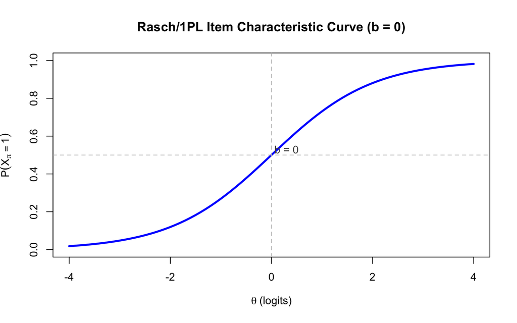

```r
# Function to calculate probability
calc_prob <- function(theta, a = 1, b = 0, c = 0) {
  c + (1 - c) * exp(a * (theta - b)) / (1 + exp(a * (theta - b)))
}

theta <- seq(-4, 4, 0.1)

# Plot Rasch ICC
plot(theta, calc_prob(theta, a = 1, b = 0), type = "l", lwd = 3, col = "blue",
     xlab = expression(theta ~ "(logits)"), ylab = expression(P(X[pi] == 1)),
     main = "Rasch/1PL Item Characteristic Curve (b = 0)",
     ylim = c(0, 1))
abline(h = 0.5, lty = 2, col = "gray")
abline(v = 0, lty = 2, col = "gray")
text(0.3, 0.53, "b = 0", col = "gray30")
```

### The 2PL Model

$$P(X_{pi} = 1 | \theta_p, a_i, b_i) =
\frac{\exp(a_i(\theta_p - b_i))}{1 + \exp(a_i(\theta_p -
b_i))}$$

- **Two item parameters:** discrimination ($a_i$) and difficulty ($b_i$)
- $a_i$ controls the slope (steepness) of the ICC at $b_i$
- Higher $a_i$ = steeper slope = better discriminating item

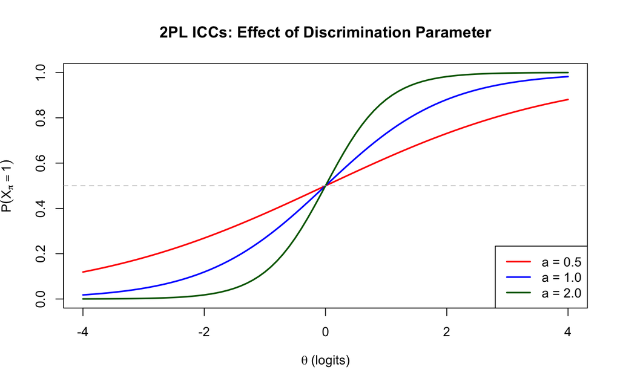

```r
# Compare different discrimination values
plot(theta, calc_prob(theta, a = 0.5, b = 0), type = "l", lwd = 2, col = "red",
     xlab = expression(theta ~ "(logits)"), ylab = expression(P(X[pi] == 1)),
     main = "2PL ICCs: Effect of Discrimination Parameter",
     ylim = c(0, 1))
lines(theta, calc_prob(theta, a = 1, b = 0), lwd = 2, col = "blue")
lines(theta, calc_prob(theta, a = 2, b = 0), lwd = 2, col = "darkgreen")
abline(h = 0.5, lty = 2, col = "gray")
legend("bottomright", legend = c("a = 0.5", "a = 1.0", "a = 2.0"),
       col = c("red", "blue", "darkgreen"), lwd = 2)
```

**Important:** In the 2PL model, different ICCs can cross. This means relative item difficulty can depend on the ability level of the test-taker.

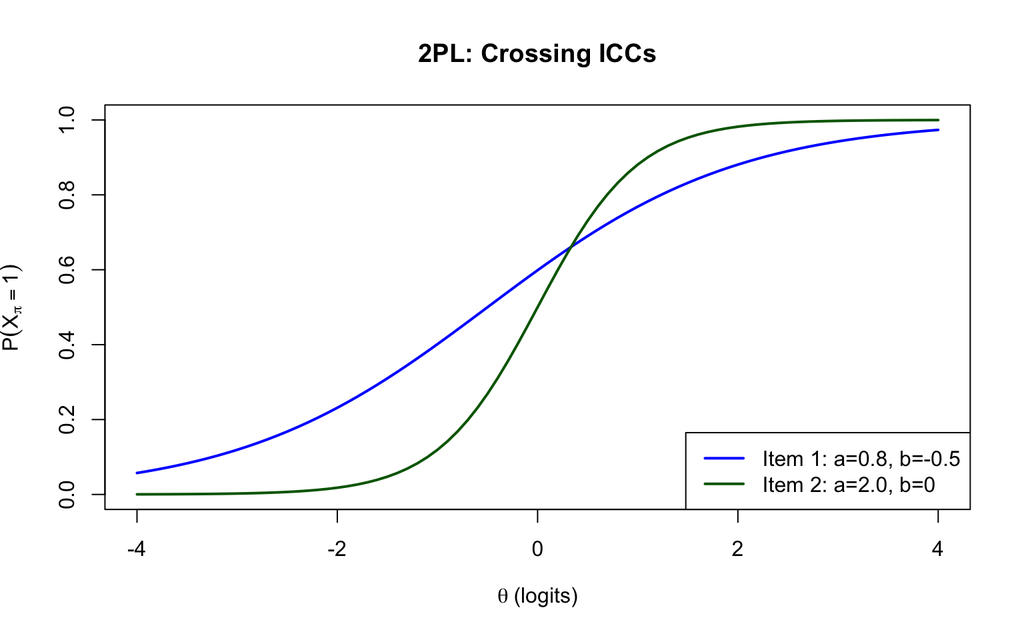

```r
plot(theta, calc_prob(theta, a = 0.8, b = -0.5), type = "l", lwd = 2, col = "blue",
     xlab = expression(theta ~ "(logits)"), ylab = expression(P(X[pi] == 1)),
     main = "2PL: Crossing ICCs",
     ylim = c(0, 1))
lines(theta, calc_prob(theta, a = 2, b = 0), lwd = 2, col = "darkgreen")
legend("bottomright", legend = c("Item 1: a=0.8, b=-0.5", "Item 2: a=2.0, b=0"),
       col = c("blue", "darkgreen"), lwd = 2)
```

### The 3PL Model

$$P(X_{pi} = 1 | \theta_p, a_i, b_i, c_i)
= c_i + (1 - c_i) \frac{\exp(a_i(\theta_p - b_i))}{1 + \exp(a_i(\theta_p
- b_i))}$$

- **Three item parameters:** discrimination ($a_i$), difficulty ($b_i$), pseudo-guessing ($c_i$)
- $c_i$ is the lower asymptote (probability of correct response by guessing)
- **Note:** In the 3PL, $b_i$ is no longer the 50% point; it corresponds to $P = 0.5 + 0.5c_i$

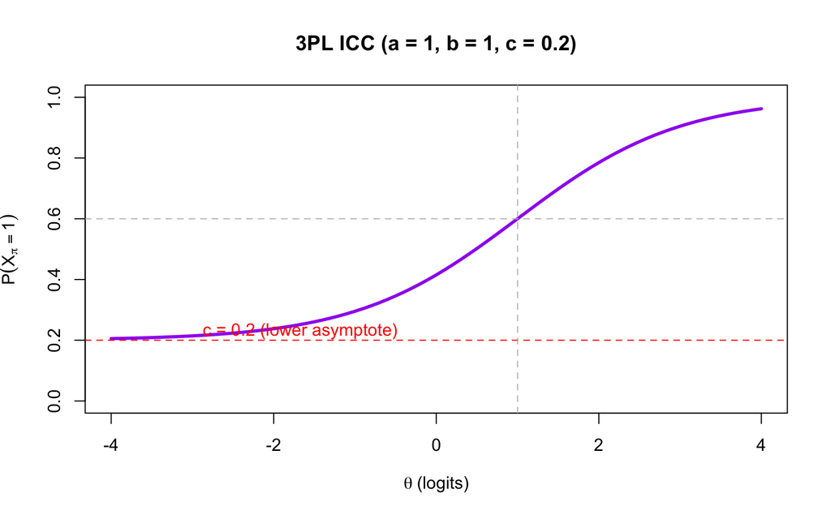

```r
# 3PL ICC
plot(theta, calc_prob(theta, a = 1, b = 1, c = 0.2), type = "l", lwd = 3, col = "purple",
     xlab = expression(theta ~ "(logits)"), ylab = expression(P(X[pi] == 1)),
     main = "3PL ICC (a = 1, b = 1, c = 0.2)",
     ylim = c(0, 1))
abline(h = 0.2, lty = 2, col = "red")
abline(h = 0.6, lty = 2, col = "gray")  # 0.5 + 0.5*0.2 = 0.6
abline(v = 1, lty = 2, col = "gray")
text(-3, 0.23, "c = 0.2 (lower asymptote)", col = "red", pos = 4)
```

### Comparing All Three Models

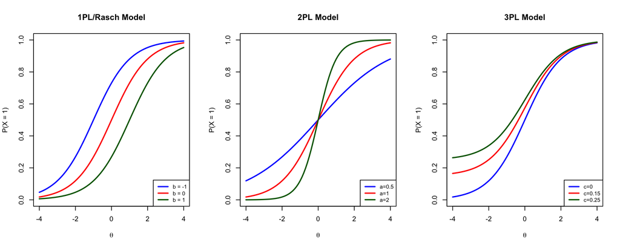

```r
par(mfrow = c(1, 3))

# 1PL
b_vals <- c(-1, 0, 1)
plot(theta, calc_prob(theta, a = 1, b = b_vals[1]), type = "l", lwd = 2,
     col = "blue", xlab = expression(theta), ylab = "P(X = 1)",
     main = "1PL/Rasch Model", ylim = c(0, 1))
lines(theta, calc_prob(theta, a = 1, b = b_vals[2]), lwd = 2, col = "red")
lines(theta, calc_prob(theta, a = 1, b = b_vals[3]), lwd = 2, col = "darkgreen")
legend("bottomright", legend = paste("b =", b_vals), col = c("blue", "red", "darkgreen"), lwd = 2, cex = 0.8)

# 2PL
plot(theta, calc_prob(theta, a = 0.5, b = 0), type = "l", lwd = 2,
     col = "blue", xlab = expression(theta), ylab = "P(X = 1)",
     main = "2PL Model", ylim = c(0, 1))
lines(theta, calc_prob(theta, a = 1, b = 0), lwd = 2, col = "red")
lines(theta, calc_prob(theta, a = 2, b = 0), lwd = 2, col = "darkgreen")
legend("bottomright", legend = c("a=0.5", "a=1", "a=2"), col = c("blue", "red", "darkgreen"), lwd = 2, cex = 0.8)

# 3PL
plot(theta, calc_prob(theta, a = 1, b = 0, c = 0), type = "l", lwd = 2,
     col = "blue", xlab = expression(theta), ylab = "P(X = 1)",
     main = "3PL Model", ylim = c(0, 1))
lines(theta, calc_prob(theta, a = 1, b = 0, c = 0.15), lwd = 2, col = "red")
lines(theta, calc_prob(theta, a = 1, b = 0, c = 0.25), lwd = 2, col = "darkgreen")
legend("bottomright", legend = c("c=0", "c=0.15", "c=0.25"), col = c("blue", "red", "darkgreen"), lwd = 2, cex = 0.8)
```

```r
par(mfrow = c(1, 1))
```

## Logits and Alternative Forms

The units of $\theta$, $b$, and $a$ are **logit** values. The $c$ parameter is on the probability scale.

For the 1PL and 2PL, we can show that:

$$\ln\left(\frac{P(X_{pi} = 1)}{1 -
P(X_{pi} = 1)}\right) = a_i(\theta_p - b_i)$$

### Slope-Intercept Form

Sometimes you’ll see the models written in slope-intercept form:

$$P(X_{pi} = 1) = c_i + (1 - c_i)
\frac{\exp(a_i\theta_p + d_i)}{1 + \exp(a_i\theta_p + d_i)}$$

where $d_i = -a_i \cdot b_i$ (or equivalently, $b_i = -d_i / a_i$).

Many IRT programs estimate $d_i$ and then convert to $b_i$.

## Activity: Three-Item Test

Consider a test with three items with the following parameters:

```r
items <- data.frame(
  Item = 1:3,
  a = c(1, 1, 2),
  b = c(-1.5, 0, 0.2),
  c = c(0.2, 0.2, 0.3)
)
knitr::kable(items, caption = "Item Parameters for Three-Item Test")
```

Item Parameters for Three-Item Test

| Item | a | b | c |
| --- | --- | --- | --- |
| 1 | 1 | -1.5 | 0.2 |
| 2 | 1 | 0.0 | 0.2 |
| 3 | 2 | 0.2 | 0.3 |

### Visualizing the ICCs

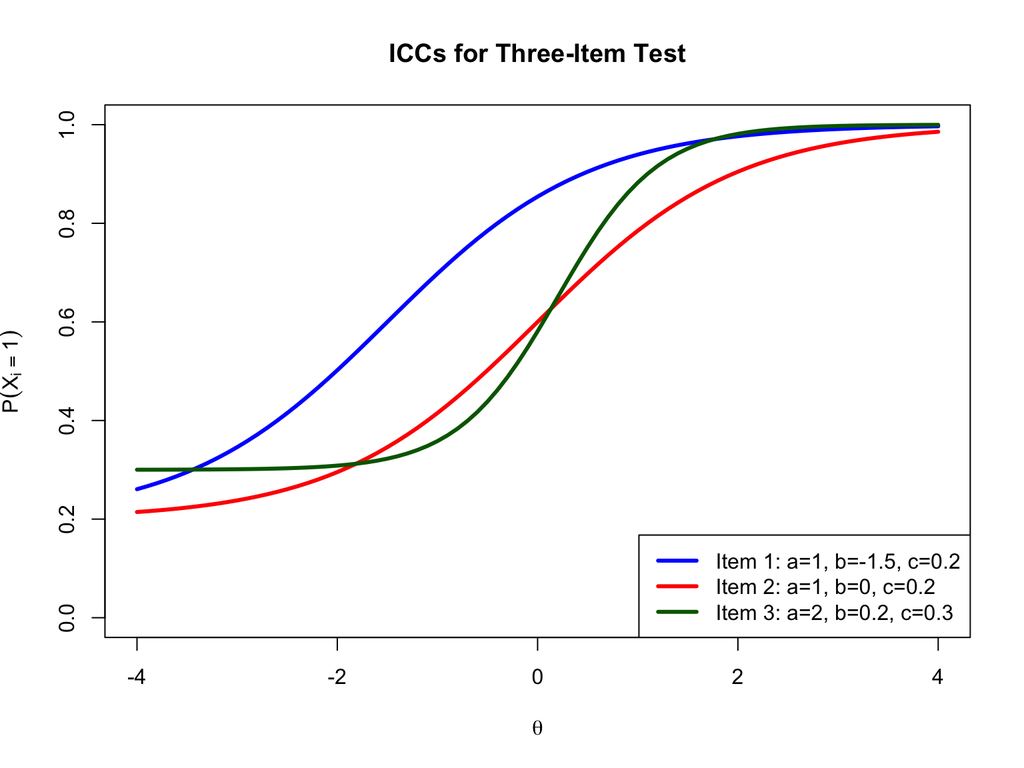

```r
theta <- seq(-4, 4, 0.1)

# Calculate probabilities for each item
p1 <- calc_prob(theta, a = 1, b = -1.5, c = 0.2)
p2 <- calc_prob(theta, a = 1, b = 0, c = 0.2)
p3 <- calc_prob(theta, a = 2, b = 0.2, c = 0.3)

plot(theta, p1, type = "l", lwd = 3, col = "blue",
     xlab = expression(theta), ylab = expression(P(X[i] == 1)),
     main = "ICCs for Three-Item Test",
     ylim = c(0, 1))
lines(theta, p2, lwd = 3, col = "red")
lines(theta, p3, lwd = 3, col = "darkgreen")
legend("bottomright",
       legend = c("Item 1: a=1, b=-1.5, c=0.2",
                  "Item 2: a=1, b=0, c=0.2",
                  "Item 3: a=2, b=0.2, c=0.3"),
       col = c("blue", "red", "darkgreen"), lwd = 3)
```

### Practice Questions

1. **Compare the difficulty of Item 1 vs. Item 2**
   - Items 1 and 2 have the same discrimination ($a = 1$) and guessing ($c = 0.2$)
   - Item 1 has $b = -1.5$, Item 2 has $b = 0$
   - Item 1 is **easier** (lower b = easier)
2. **Compare the difficulty of Item 2 vs. Item 3**
   - Different discrimination and guessing parameters make this more complex
   - The ICCs cross, so relative difficulty depends on $\theta$
3. **Calculate response vector probabilities**

```r
# Function to calculate probability of response vector
calc_vector_prob <- function(theta, responses, a, b, c) {
  prob <- 1
  for (i in 1:length(responses)) {
    p_i <- calc_prob(theta, a[i], b[i], c[i])
    if (responses[i] == 1) {
      prob <- prob * p_i
    } else {
      prob <- prob * (1 - p_i)
    }
  }
  return(prob)
}

# Item parameters
a <- c(1, 1, 2)
b <- c(-1.5, 0, 0.2)
c <- c(0.2, 0.2, 0.3)

# Theta values
theta_vals <- c(-4.0, -1.1, 0, 1.6)

# Response patterns
patterns <- list(c(0, 0, 0), c(0, 1, 0), c(1, 1, 1))
pattern_names <- c("000", "010", "111")

# Calculate probabilities
results <- matrix(NA, nrow = length(theta_vals), ncol = length(patterns))
for (i in 1:length(theta_vals)) {
  for (j in 1:length(patterns)) {
    results[i, j] <- calc_vector_prob(theta_vals[i], patterns[[j]], a, b, c)
  }
}

results_df <- data.frame(
  Theta = theta_vals,
  `000` = round(results[, 1], 3),
  `010` = round(results[, 2], 3),
  `111` = round(results[, 3], 3),
  check.names = FALSE
)

knitr::kable(results_df, caption = "Probability of Each Response Vector by Theta")
```

Probability of Each Response Vector by Theta

| Theta | 000 | 010 | 111 |
| --- | --- | --- | --- |
| -4.0 | 0.406 | 0.111 | 0.017 |
| -1.1 | 0.126 | 0.084 | 0.095 |
| 0.0 | 0.024 | 0.037 | 0.298 |
| 1.6 | 0.000 | 0.001 | 0.802 |

**Interpretation:**

- At $\theta = -4.0$: The “000” pattern (all wrong) is most likely
- At $\theta = 1.6$: The “111” pattern (all correct) is most likely
- The “010” pattern (only item 2 correct) has relatively low probability at all theta levels

## Fitting IRT Models with mirt

Now let’s use the `mirt` package in R to fit IRT models to real data.

```r
library(mirt)
```

### Load and Prepare Data

```r
forma <- read.csv("../Data/pset1_formA.csv")
forma <- forma[, 1:15]  # Use first 15 items
```

### Fit 1PL, 2PL, and 3PL Models

```r
# Fit the models
mirt_1pl <- mirt(forma, model = 1, itemtype = "Rasch", method = "EM")
mirt_2pl <- mirt(forma, model = 1, itemtype = "2PL", method = "EM")
mirt_3pl <- mirt(forma, model = 1, itemtype = "3PL", method = "EM")
```

### Extract and Compare Parameters

```r
# Extract coefficients in IRT parameterization
coef_1pl <- coef(mirt_1pl, simplify = TRUE, IRTpars = TRUE)
coef_2pl <- coef(mirt_2pl, simplify = TRUE, IRTpars = TRUE)
coef_3pl <- coef(mirt_3pl, simplify = TRUE, IRTpars = TRUE)

# Create comparison table
comparison <- data.frame(
  Item = rownames(coef_2pl$items),
  a_1PL = round(coef_1pl$items[, 1], 3),
  b_1PL = round(coef_1pl$items[, 2], 3),
  a_2PL = round(coef_2pl$items[, 1], 3),
  b_2PL = round(coef_2pl$items[, 2], 3),
  a_3PL = round(coef_3pl$items[, 1], 3),
  b_3PL = round(coef_3pl$items[, 2], 3),
  c_3PL = round(coef_3pl$items[, 3], 3)
)

knitr::kable(comparison, caption = "Parameter Estimates Across Models")
```

Parameter Estimates Across Models

|  | Item | a_1PL | b_1PL | a_2PL | b_2PL | a_3PL | b_3PL | c_3PL |
| --- | --- | --- | --- | --- | --- | --- | --- | --- |
| V1 | V1 | 1 | 1.469 | 2.223 | 0.768 | 60.370 | 0.949 | 0.081 |
| V2 | V2 | 1 | 1.590 | 2.285 | 0.821 | 59.418 | 0.960 | 0.064 |
| V3 | V3 | 1 | 2.013 | 2.371 | 1.018 | 11.383 | 1.007 | 0.044 |
| V4 | V4 | 1 | -0.604 | 1.833 | -0.327 | 1.747 | -0.290 | 0.000 |
| V5 | V5 | 1 | -0.306 | 2.152 | -0.144 | 2.048 | -0.095 | 0.000 |
| V6 | V6 | 1 | 0.774 | 1.641 | 0.461 | 1.545 | 0.532 | 0.000 |
| V7 | V7 | 1 | -0.791 | 1.595 | -0.465 | 1.537 | -0.433 | 0.000 |
| V8 | V8 | 1 | 2.066 | 2.057 | 1.098 | 1.903 | 1.186 | 0.000 |
| V9 | V9 | 1 | 0.306 | 1.580 | 0.189 | 1.531 | 0.248 | 0.000 |
| V10 | V10 | 1 | 0.853 | 2.338 | 0.450 | 2.139 | 0.532 | 0.000 |
| V11 | V11 | 1 | 2.697 | 2.353 | 1.350 | 2.027 | 1.470 | 0.000 |
| V12 | V12 | 1 | 2.342 | 2.018 | 1.249 | 1.838 | 1.347 | 0.000 |
| V13 | V13 | 1 | 0.351 | 0.956 | 0.274 | 0.932 | 0.324 | 0.000 |
| V14 | V14 | 1 | -0.065 | 1.566 | -0.033 | 1.476 | 0.015 | 0.000 |
| V15 | V15 | 1 | 0.398 | 1.468 | 0.251 | 1.412 | 0.310 | 0.000 |

### Plot ICCs

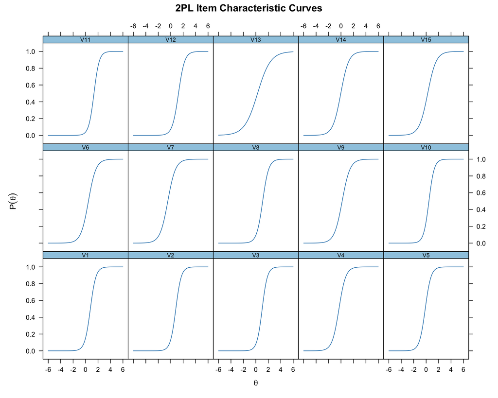

```r
# Plot ICCs for 2PL model
plot(mirt_2pl, type = 'trace', main = "2PL Item Characteristic Curves")
```

### Plot Specific Items

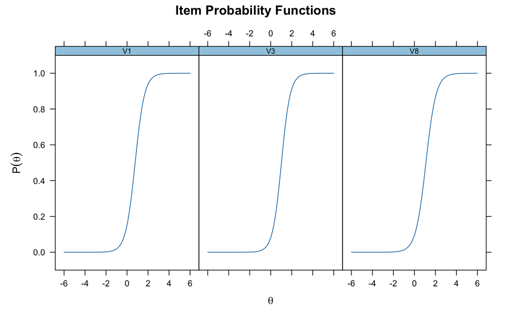

```r
# Compare specific items
plot(mirt_2pl, which.items = c(1, 3, 8), type = 'trace')
```

### Check Item Fit

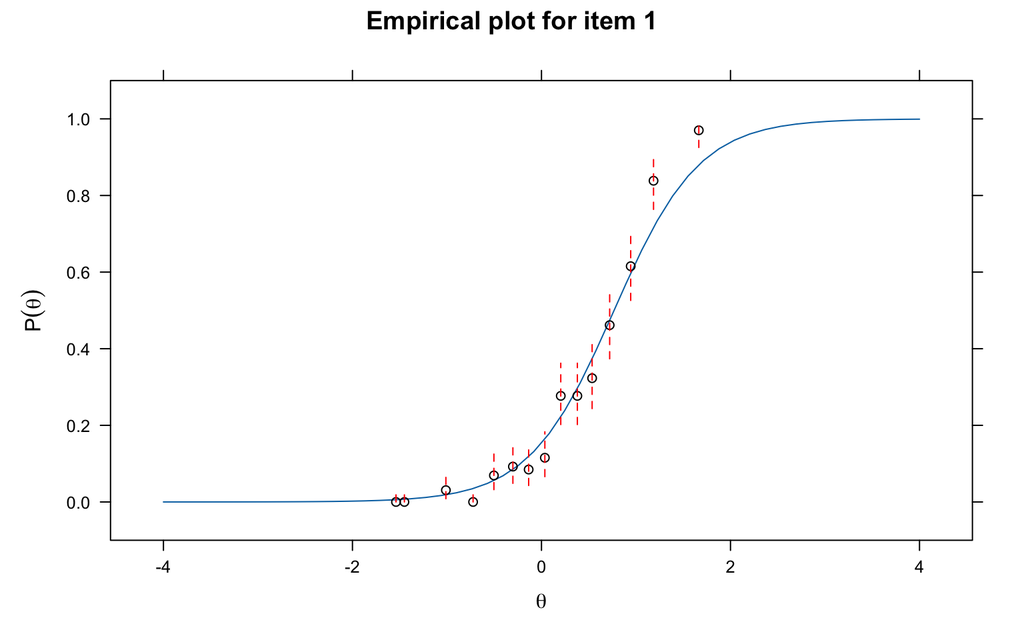

```r
# Observed vs. predicted for Item 1
itemfit(mirt_2pl, group.bins = 15, empirical.plot = 1)
```

## Summary

1. The **1PL/Rasch model** has one item parameter (difficulty) and assumes equal discrimination
2. The **2PL model** adds a discrimination parameter, allowing ICCs to have different slopes
3. The **3PL model** adds a lower asymptote (guessing) parameter
4. In the 2PL and 3PL, ICCs can cross, meaning relative item difficulty may depend on ability level
5. The `mirt` package provides a flexible framework for fitting these models in R

## Interactive Practice

For an interactive version of the three-item test activity, see the **Shiny app** in the `Shiny Apps` folder.